# p8105_hw4_jma2249.Rmd

Josie Alford

10/30/2017

```r
library(tidyverse)
library(haven)
library(janitor)
library(dplyr)
library(ggplot2)
library(lubridate)
```

# Problem Two

```r
#Read and Clean data in pols-month.csv
politicians_data = read_csv("./data/fivethirtyeight_datasets/pols-month.csv") %>%
  clean_names() %>%
  mutate(mon = floor_date(mon, "month")) %>%
  separate(mon, into = c("year", "month", "day"), convert = TRUE) %>%
  mutate(month = month.name[month]) %>%
  rename(gop = prez_gop, dem = prez_dem) %>%
  mutate(gop = replace(gop, gop == 2, 1)) %>%
  mutate(president = recode(gop, '0' = "dem", '1' = "gop")) %>%
  select(-dem, -gop, -day, -gov_gop, -gov_dem, -sen_gop, -sen_dem, -rep_dem, -rep_gop)
politicians_data #Loaded and Tidied
```

```
## # A tibble: 822 x 3
##     year     month president
##    <int>     <chr>     <chr>
##  1  1947   January       dem
##  2  1947  February       dem
##  3  1947     March       dem
##  4  1947     April       dem
##  5  1947       May       dem
##  6  1947      June       dem
##  7  1947      July       dem
##  8  1947    August       dem
##  9  1947 September       dem
## 10  1947   October       dem
## # ... with 812 more rows
```

```r
gdp_data = read_csv("./data/fivethirtyeight_datasets/GDP.csv") %>%
  clean_names() %>%
  mutate(date = floor_date(date, "month")) %>%
  separate(date, into = c("year", "month", "day"), convert = TRUE) %>%
  mutate(month = month.name[month]) %>%
  select(-day)%>%
  rename(gdp = value) %>%
  mutate(gdp = as.numeric(gdp))
gdp_data #Loaded and Tidied
```

```
## # A tibble: 273 x 3
##     year   month      gdp
##    <int>   <chr>    <dbl>
##  1  1947 January       NA
##  2  1947   April       NA
##  3  1947    July       NA
##  4  1947 October       NA
##  5  1948 January  9.50226
##  6  1948   April 10.79984
##  7  1948    July 11.75530
##  8  1948 October  7.83711
##  9  1949 January  3.45605
## 10  1949   April -0.43972
## # ... with 263 more rows
```

```r
combined_538 = gdp_data %>%
  left_join(politicians_data) %>%
  filter(!is.na(gdp)) %>%
  mutate(
    quarter = recode(month, January = "Q1", April = "Q2", July = "Q3", October = "Q4")
    ) %>%
  select(-month) %>%
  unite(qtr, c(year, quarter)) #this only includes observations with gdp values. gdp is a quarterly variable
combined_538
```

```
## # A tibble: 269 x 3
##        qtr      gdp president
##  *   <chr>    <dbl>     <chr>
##  1 1948_Q1  9.50226       dem
##  2 1948_Q2 10.79984       dem
##  3 1948_Q3 11.75530       dem
##  4 1948_Q4  7.83711       dem
##  5 1949_Q1  3.45605       dem
##  6 1949_Q2 -0.43972       dem
##  7 1949_Q3 -2.21825       dem
##  8 1949_Q4 -3.45565       dem
##  9 1950_Q1  2.10603       dem
## 10 1950_Q2  6.99301       dem
## # ... with 259 more rows
```

# Collaborator: MeOak!

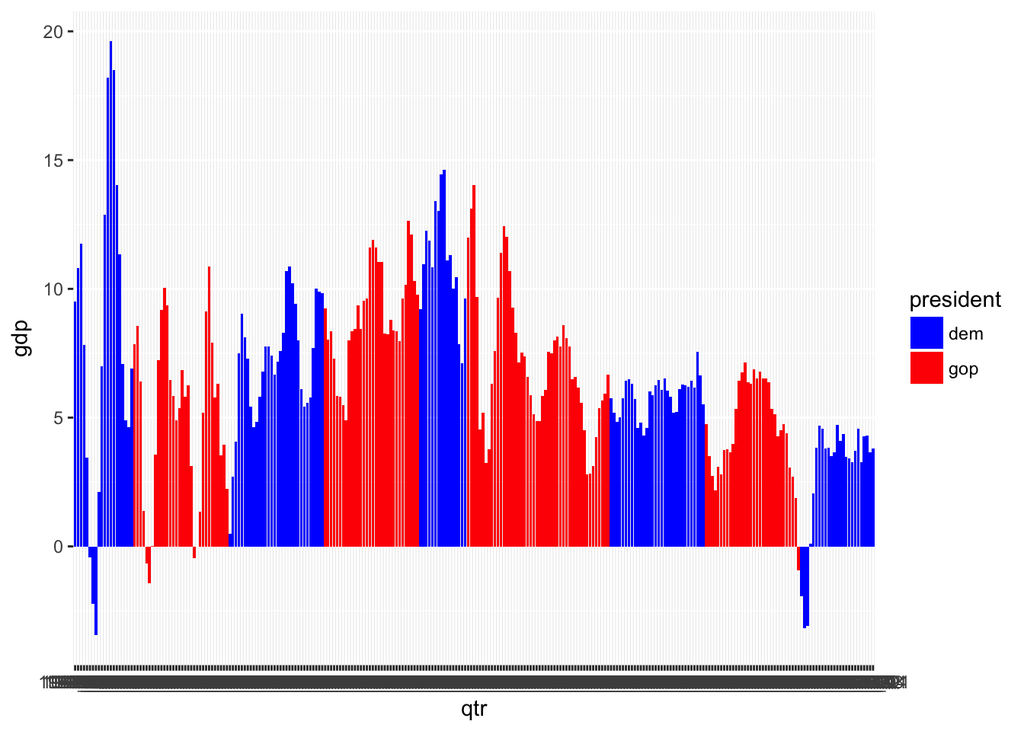

```r
###############
#For your reference, here are a couple of links to ones in "real life" :) Take your pick xx https://www.bea.gov/newsreleases/national/gdp/gdp_glance.htm and https://data.oecd.org/gdp/real-gdp-forecast.htm#indicator-chart
##############


##############
#bar plot
##############
combined_538 %>%
  ggplot(aes(x = qtr, y = gdp, fill = president)) +
  geom_bar(stat = "identity") +
  scale_fill_manual(values=c("blue", "red"))
```

# Final Analysis & Results by Josie Alford

The goal of this collaboration is to analyze the relationship between quarterly GDP and presidential party. Political party and GDP data were imported from Nate Silver’s FiveThirtyEight. Both datasets were loaded and tidied using techniques from class. The final dataset contains 3 variables: qtr (quarter and year), gdp (GDP value for each quarter), and president (presidential party during that period). There is a total of 269 observations. Examining the bar plot curated by MeOak Place, we see that over time (years in terms of quarters) GDP values have decreased.

There is no clear trend over time regarding the relationship between presidential party and GDP. GDP reaches it height during Harry S. Truman’s (D) administration (post WWII economic boost). Later during the 70s there is a peak during Jimmy Carter’s (D) administration. During Ronald Reagan’s (R) administration there is a sharp decline and sharp increase. Since George H.W. Bush’s (R) administration, GDP values have a constant trend, except during the Great Recession (end of George W. Bush’s (R) and beginning of Barack Obama’s (D) administrations). I conclude that there is a weak association between GDP values and presidential party.